# Reproducible Research: Peer Assessment 1

## Loading libraries

We will need ggplot2 and data.table libraries, let’s go load them:

```r
library(data.table)
```

```r
library(ggplot2)
```

## Loading and preprocessing the data

```r
if (!file.exists("./data/activity.csv")){
      unzip("activity.zip", exdir = "./data")
} else {
      print("There's no need to unzip!")
}
```

```
## [1] "There's no need to unzip!"
```

```r
active_data <- as.data.table(read.csv("./data/activity.csv", header = T))
active_data$date <- as.Date(as.character(active_data$date))
```

## What is mean total number of steps taken per day?

Now i’m going to calculate the total amount of steps taken per day.  
I will notice that activity data set contains some missing values, so i prefer not to remove them because i think it’s more accurate instead of counting them as zeros. Here i create new dataset based on active_data where i will have 2 columns, for total amount of steps taken per day and corresponding date.

```r
steps_per_day = active_data[, list(steps = sum(steps, na.rm = F)), by = date]
```

Now let’s check out the histogram of total number of steps…

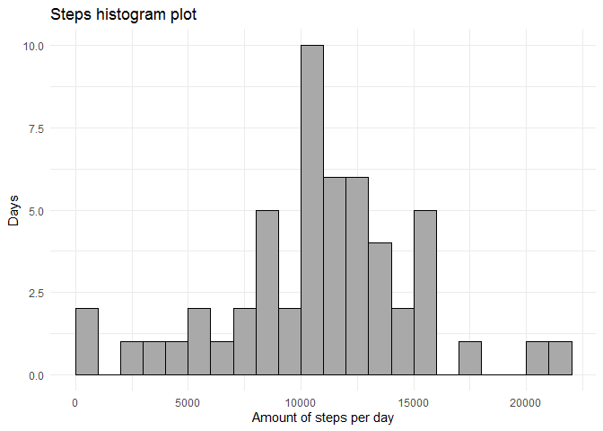

```r
plot = ggplot(data = steps_per_day, aes(x=steps))+
       geom_histogram(breaks=seq(0, 22000, by = 1000),
                      color="Black", fill="darkgrey") +
       labs(title="Steps histogram plot",
           x="Amount of steps per day", y="Days") +
       theme_minimal()

print(plot)
```

```r
steps_mean = round(mean(steps_per_day$steps, na.rm = T), 2)
steps_median = median(steps_per_day$steps, na.rm = T)
```

## What is the average daily activity pattern?

Now let’s inspect daily activity. To do that, at firts, i’m going to calculate new data set with 2 columns, first one - average number of steps taken during 5-minute interval and the second column - corresonding interval.

```r
num_steps_int <- active_data[, list(steps = mean(steps, na.rm=T)),
                                                by=interval]
```

Now let’s visualize this data by creating time-series plot of 5-minute interval (x-axis) and number of steps (y-axis).

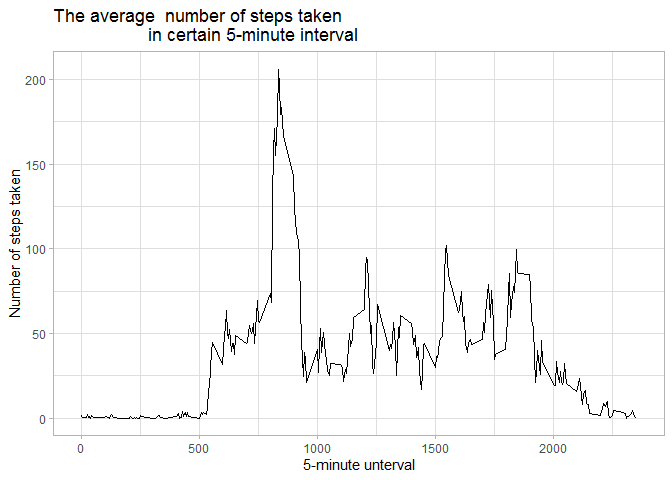

```r
plot = ggplot(data = num_steps_int,
              aes(x = interval, y = steps)) +
       geom_line() +
       labs(title="The average  number of steps taken
                   in certain 5-minute interval", x = "5-minute unterval",
                   y = "Number of steps taken") +
       theme_light()
print(plot)
```

And let’s find out certain interval in which wee have maximum of steps:

```r
pair = num_steps_int[steps == max(steps), ]
pair$steps = round(pair$steps, 2)
```

It turns out that data have maximum of 206.17 steps in 835 interval.